# Regresja i analiza wariancji - Laboratorium 3

Regresja liniowa wieloraka - wprowadzenie

Adrian Kowalski

Politechnika Krakowska

# Model regresji liniowej wielorakiej

Do tej pory rozważaliśmy model regresji liniowej prostej
$$y_i = \beta_0 + \beta_1 x_i + \epsilon_i.$$
W rzeczywistości występuje bardzo mało zależności, które da się opisać za pomocą dokładnie jednej zmiennej objaśniającej. Uogólnimy nasze podejście do regresji liniowej wprowadzając nowe zmienne objaśniające i sprowadzając model do postaci.
$$y_i = \beta_0 + \beta_1 x_{i1} + \beta_2 x_{i2}
+ \dots + \beta_k x_{ik} + \varepsilon_i.$$
Gdzie $\varepsilon_i$ nadal będą zmiennymi losowymi o rozkładzie $N(0,\sigma^2)$ dla pewnej stałej wariancji $\sigma^2$. Wszelkie pozostałe założenia modelu, które poczyniliśmy przy regresji liniowej prostej pozostają, dojdzie natomiast dodatkowe założenie wynikające z postaci współczynników. Standardowo będziemy oznaczać tak jak poprzednio
$$\hat{y_i} = \beta_0 + \beta_1 x_{i1} + \beta_2
x_{i2} + \dots + \beta_k x_{ik}$$

# Macierzowa postać modelu regresji

Podobnie jak w przypadku regresji liniowej prostej będziemy chcieli zminimalizować błąd średniokwadratowy naszego estymatora. W tym wypadku natomiast przybiera on nieco inną postać
$$MSE = \frac{\sum_{i=1}^n \varepsilon_i^2}{n - (k + 1)} =
\frac{\sum_{i=1}^n (y_i - \hat{y}_i )^2}{n - (k+1)} = \frac{\sum_{i=1}^n
(y_i - \beta_0 - \beta_1x_{i1} - \dots - \beta_k x_{ik} )^2}{n -
(k+1)}$$
W tym celu spojrzymy na nasz model z nieco innej perspektywy. Spójrzmy jeszcze raz na równanie regresji
$$y_i = \beta_0 + \beta_1 x_{i1} + \beta_2 x_{i2}
+ \dots + \beta_k x_{ik} + \varepsilon_i.$$
Dla dowolnego ustalonego $i$ możemy je zapisać w formie
$$y_i = [1, x_{i1}, x_{i2}, \dots,
x_{ik}]\left[\begin{array}{c} \beta_0 \\ \beta_1 \\ \dots \\ \beta_k
\end{array} \right] + \varepsilon_i.$$

Dzięki tej formie zapisu możemy spojrzeć teraz na model całościowo, uwzględniając na raz wszystkie dane.
$$\left[\begin{array}{c} y_1 \\ y_2 \\ \dots \\ y_n
\end{array} \right] = \left[\begin{array}{c} 1 \; x_{11} \; \dots x_{1k}
\\ 1 \; x_{21} \; \dots \; x_{2k} \\ \dots \\ 1 \; x_{n1} \; \dots \;
x_{nk} \end{array} \right] \left[\begin{array}{c} \beta_0 \\ \beta_1 \\
\dots \\ \beta_k \end{array} \right] + \left[\begin{array}{c}
\varepsilon_1 \\ \varepsilon_2 \\ \dots \\ \varepsilon_n \end{array}
\right].$$
Od tej pory będziemy używać zapisu skrótowego
$$\boldsymbol{y} = \left[\begin{array}{c} y_1 \\
y_2 \\ \dots \\ y_n \end{array} \right]$$
$$\boldsymbol{X} = \left[\begin{array}{c} 1 \;
x_{11} \; \dots x_{1k} \\ 1 \; x_{21} \; \dots \; x_{2k} \\ \dots \\ 1
\; x_{n1} \; \dots \; x_{nk} \end{array} \right]$$

$$\boldsymbol{\beta} =
\left[\begin{array}{c} \beta_0 \\ \beta_1 \\ \dots \\ \beta_k
\end{array} \right]$$
$$\boldsymbol{\varepsilon} = \left[\begin{array}{c} \varepsilon_1 \\
\varepsilon_2 \\ \dots \\ \varepsilon_n \end{array} \right]$$
Biorąc pod uwagę wprowadzone oznaczenia, nasz model w skrótowej formie przyjmuje postać
$$\boldsymbol{y} =
\boldsymbol{X}\boldsymbol{\beta} + \boldsymbol{\varepsilon}.$$

# Wyznaczenie współczynników modelu liniowego

W celu wyznaczenia ogólnego wzoru na współczynniki modelu regresji liniowej wielorakiej możemy postąpić tak jak poprzednio, po przez minimalizacje błędu średniokwadratowego. Takie rozumowanie prowadzi chociażby autor [tutaj](http://home.iitk.ac.in/~shalab/regression/Chapter3-Regression-MultipleLinearRegressionModel.pdf). Można też wyprowadzić ten wzór za pomocą rozkładu SVD macierzy tak jak robią to autorzy [tutaj](http://databookuw.com/databook.pdf). My skorzystamy ze wzoru na tzw. (lewą) pseudo-odwrotność Moora-Penrose’a
$$X^\dagger = (X^TX)^{-1}X^T.$$
Jej zastosowanie daje nam wzór na współczynniki
$$(X^TX)^{-1}X^T\boldsymbol{y} = \beta.$$
Wstawiamy ten wzór do modelu i otrzymujemy
$$\hat{y} = X(X^TX)^{-1}X^T\boldsymbol{y}.$$

Macierz
$$H := X(X^TX)^{-1}X^T$$
nazywa się czasem *hat matrix*.

# Założenia modelu regresji wielorakiej

Zauważmy, że chociażby z faktu, że wykorzystujemy macierz $(X^TX)^{-1}$, ta odwrotność musi istnieć. Musimy zatem dołożyć kolejne założenie do naszej klasycznej listy założeń, mówiące o pełnym rzędzie kolumnowym macierzy $X$, co przekłada się po prostu na brak struktury zależności między zmiennymi objaśniającymi $x_1, x_2, \dots, x_k$. Podsumowując, wykorzystując zapis macierzowy, nasze założenia to

- liniowa zależność między zmienną objaśnianą, a objaśniającą postaci $\boldsymbol{y} = \boldsymbol{X}\boldsymbol{\beta} + \boldsymbol{\varepsilon}$,
- wektor losowy $\varepsilon$ ma średnią $\boldsymbol{0}$,
- wektor losowy $\varepsilon$ ma macierz kowariancji postaci $\sigma^2 \boldsymbol{I}$, gdzie $\sigma^2$ to pewna liczba rzeczywista,
- zmienne losowe $\varepsilon_i, \varepsilon_j$ są ze sobą niezależne, dla różnych $i,j$,
- wektor losowy $\varepsilon$ ma wielowymiarowy rozkład normalny $N(0, \sigma^2 \boldsymbol{I})$,
- rzadna ze zmiennych objaśniających nie jest kombinacją liniową pozostałych, innymi słowy, zmienne objaśniające są liniowo niezależne, a macierz $X$ jest pełnego rzędu kolumnowego.

O jakości estymatora, który wyznaczyliśmy w poprzednim rozdziale w sytuacji, gdy powyższe założenia są spełnione mówi twierdzenie [Gaussa-Markowa](https://en.wikipedia.org/wiki/Gauss%E2%80%93Markov_theorem).

# Współczynnik determinacji $R^2$.

Podobnie jak w przypadku regresji liniowej prostej, możemy w celu oceny jakości modelu skorzystać z współczynnika determinacji $R^2$. Ma on niestety poważną wadę w przypadku regresji liniowej wielorakiej. Przypomnijmy

$$R^2 = 1 - \frac{\sum_{i=1}^n
\varepsilon_i^2}{\sum_{i=1}^n(y_i - \overline{y})^2}.$$

Dodanie kolejnej zmiennej do modelu nigdy nie podniesie sumy kwadratów reszt, może ją tylko zmniejszyć lub nie zmienić. Zatem $R^2$ będzie większe im więcej zmiennych dodamy do modelu, co nie koniecznie będzie świadczyć o większej jakości modelu. Aby z tym walczyć wprowadzamy tzw. skorygowane $R^2$ (adjusted $R^2$ dane wzorem
$$R^2 = 1 - \frac{n - 1}{n - (k+1)}(1 - R^2).$$

Skorygowane $R^2$ bierze pod uwagę jakość modelu i ilość zmiennych objaśniających, więc może być używane do porówynywania różnych modeli.

# Statystyka F

Wywołując summary() na danym modelu regresji liniowej otrzymujemy również wartość statystyki testowej $F$ dla tego modelu. Statystyka ta jest ściśle związana z analizą wariancji i będziemy o niej jeszcze mówić, natomiast warto teraz wspomnieć o hipotezach testu, który ta statystyka wykonuje.
$$\begin{array}{ll} H_0: &
\beta_1 = \beta_2 = \dots = \beta_k = 0 \\ H_1: & \exists_{k}
\; \beta_k \neq 0 \end{array}$$
Innymi słowy, wysoka $p$-wartość testu $F$ świadczy o tym, że nasz model ma wyłącznie zerowe współczynniki.

# Ćwiczenie: Model wyceny używanych aut

Skorzystamy z danych [CARS DATASET (Audi, BMW, Ford, Hyundai, Skoda, VW)](https://www.kaggle.com/aishwaryamuthukumar/cars-dataset-audi-bmw-ford-hyundai-skoda-vw). Na podstawie tych danych zbudujemy różne modele regresji liniowej wielorakiej i porównamy je między sobą przy pomocy skorygowanego $R^2$.

| model | age | price | transmission | mileage | fuelType | tax | mpg | engineSize | Make | random_col |
| --- | --- | --- | --- | --- | --- | --- | --- | --- | --- | --- |
| 5 Series | 3 | 38995 | Semi-Auto | 3383 | Diesel | 145 | 51.4 | 3.0 | BMW | 3.398151 |
| A4 | 4 | 27850 | Semi-Auto | 8874 | Petrol | 150 | 36.7 | 3.0 | audi | 3.854673 |
| X3 | 11 | 8440 | Automatic | 85000 | Diesel | 165 | 50.4 | 2.0 | BMW | 2.931284 |
| 5 Series | 6 | 16399 | Automatic | 45036 | Petrol | 160 | 44.8 | 2.0 | BMW | 3.190490 |
| Polo | 4 | 11692 | Manual | 26652 | Petrol | 150 | 64.2 | 1.0 | vw | 3.717710 |
| Fiesta | 5 | 11512 | Manual | 13146 | Diesel | 145 | 88.3 | 1.5 | Ford | 2.865354 |

Zacznijmy od modelu, który przewiduje cenę za pomocą wieku auta.

```r
library(caret)
split <- createDataPartition(cars_sample$price, p=0.75, list=FALSE)
cars_sample_train <- cars_sample[split,]
cars_sample_test <- cars_sample[-split,]
```

```r
cars_model <- lm(price ~ age, data = cars_sample_train)
summary(cars_model)
```

```
##
## Call:
## lm(formula = price ~ age, data = cars_sample_train)
##
## Residuals:
##    Min     1Q Median     3Q    Max
## -13525  -5032  -1185   3769  36475
##
## Coefficients:
##             Estimate Std. Error t value Pr(>|t|)
## (Intercept)  28368.9      739.5   38.36   <2e-16 ***
## age          -2426.8      138.9  -17.47   <2e-16 ***
## ---
## Signif. codes:  0 '***' 0.001 '**' 0.01 '*' 0.05 '.' 0.1 ' ' 1
##
## Residual standard error: 7470 on 712 degrees of freedom
## Multiple R-squared:  0.2999, Adjusted R-squared:  0.299
## F-statistic: 305.1 on 1 and 712 DF,  p-value: < 2.2e-16
```

```r
model_summary(cars_model, cars_sample_test, cars_sample_test$price)
```

```
## [1] "Wartośći charakterystyk liczbowych modelu."
## [1] "------------------------------------------"
## Treningowe R^2 wyniosło:  0.2999423
##  Treningowe "poprawione" R^2 wyniosło:  0.2989591
##  Kryterium informacyjne Akaikego (AIC) wyniosło:  14766.03
##  ---------------------------------------------
##  Charakterystyki "out-of-sample"
##  Charakterystyka |   train  |   test   |
##  RMSE wyniosło:  | 7469.778 | 9162.56 |
##  MAE wyniosło:   | 5572.764 | 6564.234 |
##  MAPE wyniosło:  | 40.37 %| 47.15 %|
```

Spróbujmy poprawić jakość modelu wykorzystując eksploracyjną analizę danych. Zbadajmy histogram zmiennej objaśniającej w celu określenia charakteru jej rozkładu.

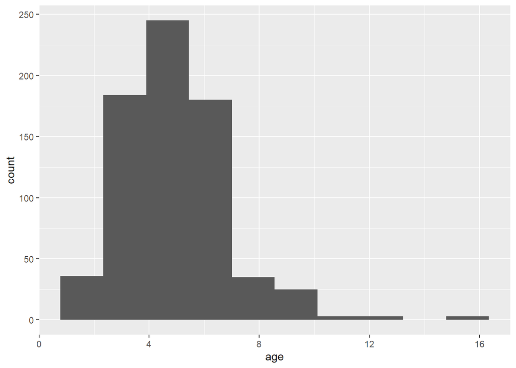

```r
ggplot(cars_sample_train, aes(x = age)) + geom_histogram(bins = 10)
```

Zmienna objaśniająca ma bardzo mało obserwacji w prawym ogonie, spróbujmy złagodzić wpływ tego efektu dokonując transformacji logarytmem.

```r
cars_model <- lm(price ~ log(age), data=cars_sample_train)
summary(cars_model)
```

```
##
## Call:
## lm(formula = price ~ log(age), data = cars_sample_train)
##
## Residuals:
##    Min     1Q Median     3Q    Max
## -17440  -4495   -872   3410  32987
##
## Coefficients:
##             Estimate Std. Error t value Pr(>|t|)
## (Intercept)  36708.0     1058.7   34.67   <2e-16 ***
## log(age)    -13385.4      675.4  -19.82   <2e-16 ***
## ---
## Signif. codes:  0 '***' 0.001 '**' 0.01 '*' 0.05 '.' 0.1 ' ' 1
##
## Residual standard error: 7167 on 712 degrees of freedom
## Multiple R-squared:  0.3555, Adjusted R-squared:  0.3546
## F-statistic: 392.7 on 1 and 712 DF,  p-value: < 2.2e-16
```

Bez narażania się na przeuczenie naszego modelu ciężko jest znaleźć dodatkowe transformacje, które ulepszą nasz model. Zbadajmy jeszcze jego charakterystyki liczbowe.

```r
model_summary(cars_model, cars_sample_test, cars_sample_test$price)
```

```
## [1] "Wartośći charakterystyk liczbowych modelu."
## [1] "------------------------------------------"
## Treningowe R^2 wyniosło:  0.3555042
##  Treningowe "poprawione" R^2 wyniosło:  0.354599
##  Kryterium informacyjne Akaikego (AIC) wyniosło:  14706.99
##  ---------------------------------------------
##  Charakterystyki "out-of-sample"
##  Charakterystyka |   train  |   test   |
##  RMSE wyniosło:  | 7167.222 | 8476.622 |
##  MAE wyniosło:   | 5307.809 | 6068.719 |
##  MAPE wyniosło:  | 36.9 %| 40.73 %|
```

#Model drugi

W takim razie najprostszym kolejnym krokiem jaki możemy podjąć jest dodanie kolejnych zmiennych do modelu!

```r
cars_model <- lm(price ~ log(age)+mpg, data=cars_sample_train)
summary(cars_model)
```

```
##
## Call:
## lm(formula = price ~ log(age) + mpg, data = cars_sample_train)
##
## Residuals:
##      Min       1Q   Median       3Q      Max
## -13892.1  -3815.6   -564.5   3354.0  27610.3
##
## Coefficients:
##             Estimate Std. Error t value Pr(>|t|)
## (Intercept) 50489.64    1246.54   40.50   <2e-16 ***
## log(age)    -9538.50     625.83  -15.24   <2e-16 ***
## mpg          -362.72      22.51  -16.11   <2e-16 ***
## ---
## Signif. codes:  0 '***' 0.001 '**' 0.01 '*' 0.05 '.' 0.1 ' ' 1
##
## Residual standard error: 6139 on 711 degrees of freedom
## Multiple R-squared:  0.5279, Adjusted R-squared:  0.5266
## F-statistic: 397.5 on 2 and 711 DF,  p-value: < 2.2e-16
```

```r
model_summary(cars_model, cars_sample_test, cars_sample_test$price)
```

```
## [1] "Wartośći charakterystyk liczbowych modelu."
## [1] "------------------------------------------"
## Treningowe R^2 wyniosło:  0.5278809
##  Treningowe "poprawione" R^2 wyniosło:  0.5265529
##  Kryterium informacyjne Akaikego (AIC) wyniosło:  14486.76
##  ---------------------------------------------
##  Charakterystyki "out-of-sample"
##  Charakterystyka |   train  |   test   |
##  RMSE wyniosło:  | 6138.634 | 6917.177 |
##  MAE wyniosło:   | 4565.035 | 5065.015 |
##  MAPE wyniosło:  | 32.74 %| 36.38 %|
```

Dodanie zmiennej na pewno znacznie i korzystnie wpłynęło na jakość modelu pod wieloma względami. Należy niestety jednak uważać i badać z jakich w zasadzie charakterystyk liczbowych modelu korzystamy w celu określenia jego jakości. Dodajmy teraz do modelu kolumne szumu losowego, w żaden sposób nie skorelowanego ze zmienną objaśnianą.

# Model z losową kolumną

```r
bad_cars_model <- lm(price ~ log(age) + random_col, data=cars_sample_train)
summary(bad_cars_model)
```

```
##
## Call:
## lm(formula = price ~ log(age) + random_col, data = cars_sample_train)
##
## Residuals:
##    Min     1Q Median     3Q    Max
## -17442  -4499   -918   3406  33002
##
## Coefficients:
##              Estimate Std. Error t value Pr(>|t|)
## (Intercept)  36923.65    1896.62  19.468   <2e-16 ***
## log(age)    -13382.49     676.22 -19.790   <2e-16 ***
## random_col     -73.32     534.78  -0.137    0.891
## ---
## Signif. codes:  0 '***' 0.001 '**' 0.01 '*' 0.05 '.' 0.1 ' ' 1
##
## Residual standard error: 7172 on 711 degrees of freedom
## Multiple R-squared:  0.3555, Adjusted R-squared:  0.3537
## F-statistic: 196.1 on 2 and 711 DF,  p-value: < 2.2e-16
```

```r
model_summary(bad_cars_model, cars_sample_test, cars_sample_test$price)
```

```
## [1] "Wartośći charakterystyk liczbowych modelu."
## [1] "------------------------------------------"
## Treningowe R^2 wyniosło:  0.3555212
##  Treningowe "poprawione" R^2 wyniosło:  0.3537083
##  Kryterium informacyjne Akaikego (AIC) wyniosło:  14708.97
##  ---------------------------------------------
##  Charakterystyki "out-of-sample"
##  Charakterystyka |   train  |   test   |
##  RMSE wyniosło:  | 7172.165 | 8476.097 |
##  MAE wyniosło:   | 5306.964 | 6066.946 |
##  MAPE wyniosło:  | 36.88 %| 40.71 %|
```

# Model trzeci

```r
cars_model <- lm(price ~ log(age)+mpg+engineSize, data=cars_sample_train)
summary(cars_model)
```

```
##
## Call:
## lm(formula = price ~ log(age) + mpg + engineSize, data = cars_sample_train)
##
## Residuals:
##      Min       1Q   Median       3Q      Max
## -20478.4  -2429.4    -34.1   2313.1  22927.7
##
## Coefficients:
##             Estimate Std. Error t value Pr(>|t|)
## (Intercept)  27386.2     1247.4   21.95  < 2e-16 ***
## log(age)    -11289.9      450.3  -25.07  < 2e-16 ***
## mpg           -146.5       18.0   -8.14 1.77e-15 ***
## engineSize    8507.2      322.9   26.34  < 2e-16 ***
## ---
## Signif. codes:  0 '***' 0.001 '**' 0.01 '*' 0.05 '.' 0.1 ' ' 1
##
## Residual standard error: 4368 on 710 degrees of freedom
## Multiple R-squared:  0.7613, Adjusted R-squared:  0.7603
## F-statistic: 754.6 on 3 and 710 DF,  p-value: < 2.2e-16
```

```r
model_summary(cars_model, cars_sample_test, cars_sample_test$price)
```

```
## [1] "Wartośći charakterystyk liczbowych modelu."
## [1] "------------------------------------------"
## Treningowe R^2 wyniosło:  0.7612596
##  Treningowe "poprawione" R^2 wyniosło:  0.7602508
##  Kryterium informacyjne Akaikego (AIC) wyniosło:  14001.92
##  ---------------------------------------------
##  Charakterystyki "out-of-sample"
##  Charakterystyka |   train  |   test   |
##  RMSE wyniosło:  | 4368.321 | 4553.448 |
##  MAE wyniosło:   | 3093.59 | 3069.692 |
##  MAPE wyniosło:  | 21.07 %| 20.1 %|
```

# Model czwarty

Dodajmy kolejną zmienną i zaobserwujmy jej wpływ na jakość modelu.

```r
cars_model <- lm(price ~ log(age)+mpg+engineSize+mileage, data=cars_sample)
summary(cars_model)
```

```
##
## Call:
## lm(formula = price ~ log(age) + mpg + engineSize + mileage, data = cars_sample)
##
## Residuals:
##      Min       1Q   Median       3Q      Max
## -21235.6  -2185.5     12.4   1991.5  24434.6
##
## Coefficients:
##               Estimate Std. Error t value Pr(>|t|)
## (Intercept)  2.447e+04  1.198e+03  20.415  < 2e-16 ***
## log(age)    -9.481e+03  5.269e+02 -17.994  < 2e-16 ***
## mpg         -1.381e+02  1.557e+01  -8.872  < 2e-16 ***
## engineSize   9.286e+03  2.813e+02  33.006  < 2e-16 ***
## mileage     -6.647e-02  1.090e-02  -6.096 1.58e-09 ***
## ---
## Signif. codes:  0 '***' 0.001 '**' 0.01 '*' 0.05 '.' 0.1 ' ' 1
##
## Residual standard error: 4319 on 945 degrees of freedom
## Multiple R-squared:  0.7853, Adjusted R-squared:  0.7844
## F-statistic: 863.9 on 4 and 945 DF,  p-value: < 2.2e-16
```

```r
model_summary(cars_model, cars_sample_test, cars_sample_test$price)
```

```
## [1] "Wartośći charakterystyk liczbowych modelu."
## [1] "------------------------------------------"
## Treningowe R^2 wyniosło:  0.7852638
##  Treningowe "poprawione" R^2 wyniosło:  0.7843549
##  Kryterium informacyjne Akaikego (AIC) wyniosło:  18607.37
##  ---------------------------------------------
##  Charakterystyki "out-of-sample"
##  Charakterystyka |   train  |   test   |
##  RMSE wyniosło:  | 4318.814 | 4351.951 |
##  MAE wyniosło:   | 3006.059 | 2945.88 |
##  MAPE wyniosło:  | 20.47 %| 19.68 %|
```

# Macierz korelacji

Głównym narzędziem, które pomaga nam badać, które zmienne przydadzą się w znaczny sposób w modelu jest macierz korelacji. Pomaga ona również wykryć kolinearność zmiennych objaśniających, która oczywiście jest niekorzystna. Macierz korelacji najczęściej przedstawiamy w formie graficznej.

```r
cars_sample_cormat <- round(cor(cars_sample[,c(2,3,5,7,8,9)]),2)
cars_sample_cormat
```

```
##              age price mileage   tax   mpg engineSize
## age         1.00 -0.52    0.73 -0.16  0.24       0.02
## price      -0.52  1.00   -0.44  0.35 -0.62       0.66
## mileage     0.73 -0.44    1.00 -0.19  0.29       0.07
## tax        -0.16  0.35   -0.19  1.00 -0.59       0.35
## mpg         0.24 -0.62    0.29 -0.59  1.00      -0.46
## engineSize  0.02  0.66    0.07  0.35 -0.46       1.00
```

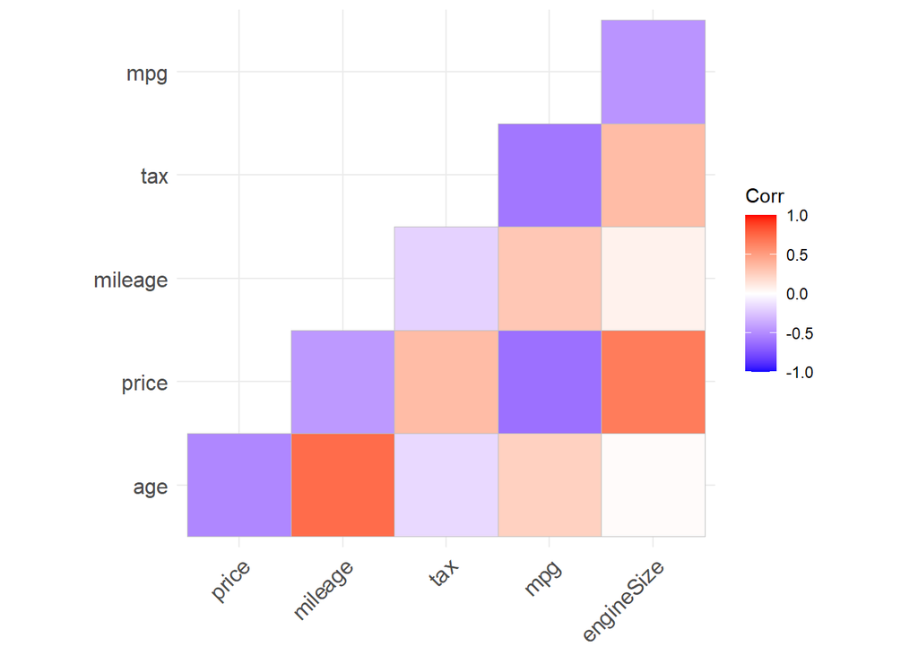

```r
library(ggcorrplot)
ggcorrplot(cars_sample_cormat, type='lower')
```